# Mountain Pine Beetle Red Top Spread Model

Barry J. Cooke and Alex M. Chubaty

August 13, 2015

The goal of this model is to simulate the spread of mountain pine beetle outbreaks as a function of the growth and dispersal of beetle-killed trees, called “red tops”. Recruitment is an annual process, with the inter-annual recruitment function taking a variety of possible forms, depending who one takes as an authority on the question. Berryman (1979) was an early pioneer who inspired much work in the area, and there are several possible interpretation of the data he used from Glacier and Yellowtone National Parks in MO and WY the 1960s. Consequently, the module offers the option of using any of four possible interpretations. Two addiitonal options are forthcoming at the time of writing. The first of these is a high-order polynomial fit to Berryaman’s hand-drawn curve. The second is the linearized multi-niche model of Berryman (1999), which, oddly & inexplicably, held endemic-niche dynamics as a fast process (`R[t] ~ X[t-1]`), and epidemic-niche dynamics as a lagged process (`R[t] ~ X[t-2]`).

Calculating the initial density of red tops and the effect of growth in their number requires read and write access to a forest landscape of some sort.

Dispersal is currently a stub.

### Install and load necessary packages

Install the most recent version of the `SpaDES` package.

```r
# from CRAN (not updated very frequently):
install.packages("SpaDES")

# most recent stable development version:
install.packages("SpaDES", repos="http://132.156.149.95") # NRCAN access only

# the most recent development version (unstable):
devtools::install_github("PredictiveEcology/SpaDES", ref="development")
```

Load the packages needed to run the code blocks in this document.

Additional packages loaded automatically by the modules do not need to be explicitly loaded at this point:

```r
library(ggplot2)
library(RandomFields) # temporarily used to generate random maps
library(raster)
library(RColorBrewer)
```

### Simulation setup

#### Berryman’s 1979 data (fitted)

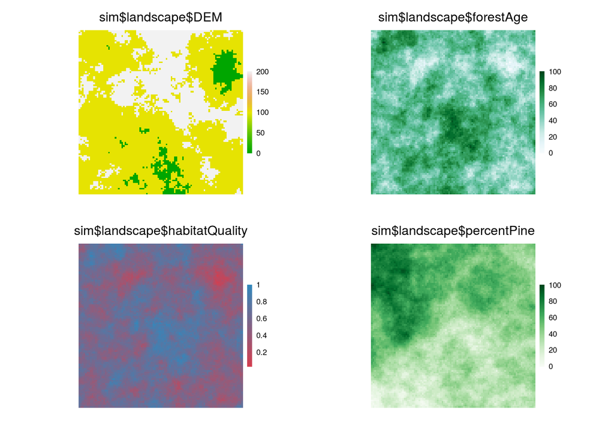

```
## class       : RasterLayer
## dimensions  : 100, 100, 10000  (nrow, ncol, ncell)
## resolution  : 1, 1  (x, y)
## extent      : -50, 50, -50, 50  (xmin, xmax, ymin, ymax)
## coord. ref. : NA
## data source : in memory
## names       : climate
## values      : 3.630665, 13.63067  (min, max)
```

```
## legendRange is not wide enough, scaling to min and max raster values
```

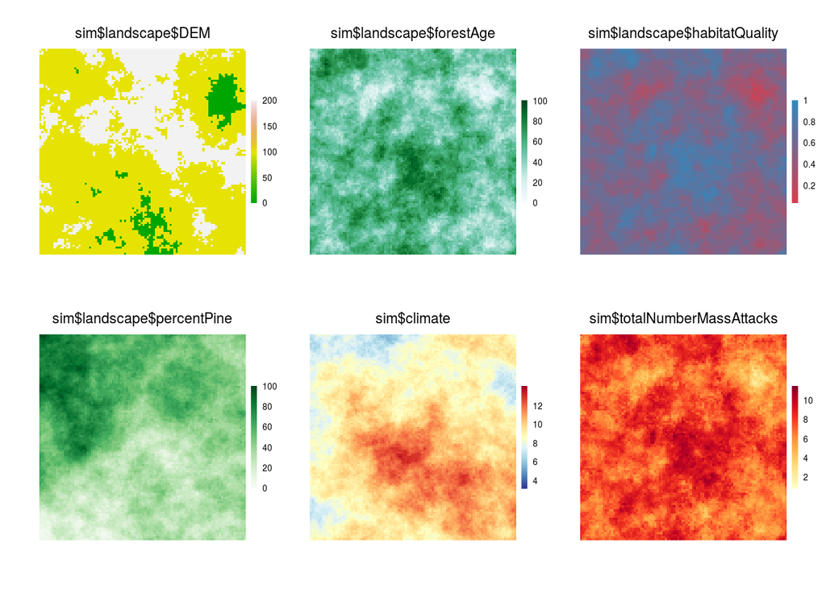

```
## legendRange is not wide enough, scaling to min and max raster values
```

[figure not shown]

[output not shown]

[output cut: 25 more lines]

```
## resolution  : 1, 1  (x, y)
## extent      : -50, 50, -50, 50  (xmin, xmax, ymin, ymax)
## coord. ref. : NA
## data source : in memory
## names       : climate
## values      : 31.75912, 41.75912  (min, max)
##
## class       : RasterLayer
## dimensions  : 100, 100, 10000  (nrow, ncol, ncell)
## resolution  : 1, 1  (x, y)
## extent      : -50, 50, -50, 50  (xmin, xmax, ymin, ymax)
## coord. ref. : NA
## data source : in memory
## names       : climate
## values      : 34.8961, 44.8961  (min, max)
```

```r
clearPlot()

simB79fit <- simInit(
  times=list(start=0.0, end=10.0, timeunit="year"),
  params=list(
    .globals=list(stackName="landscape", climateMap="climate"),
    MPBRedTopGrowth_B79fit=list(.plotInitialTime=1, .plotInterval=1),
    MPBRedTopLandscape=list(.plotInitialTime=1, .plotInterval=1, nx=100, ny=100),
    MPBRedTopClimate=list(.plotInitialTime=1, .plotInterval=1, nx=100, ny=100, updateInterval=1),
    MPBRedTopMassAttacks=list(.plotInitialTime=1, .plotInterval=NA),
    MPBRedTopImpacts=list(.plotInitialTime=1, .plotInterval=1)
  ),
  modules=list("MPBRedTopLandscape",
               "MPBRedTopClimate",
               "MPBRedTopMassAttacks",
               "MPBRedTopDispersal_Null",
               "MPBRedTopGrowth_B79fit", ## specify which growth module is used
               "MPBRedTopImpacts"),
  paths=list(modulePath="./modules")
) %>% spades(., debug=FALSE)
```

Simulation diagrams:

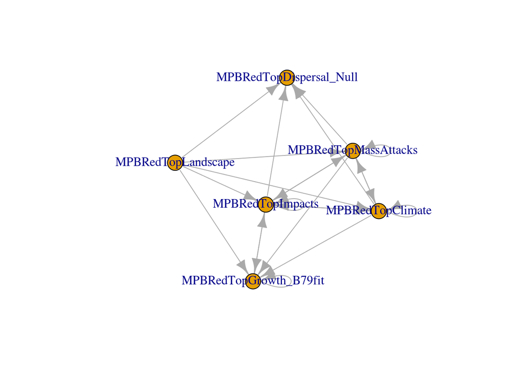

```r
moduleDiagram(simB79fit)
```

```r
objectDiagram(simB79fit)
```

[interactive chart not shown]

```r
eventDiagram(simB79fit, startDate="0000-06-01") # startDate required
```

[interactive chart not shown]

#### Berryman’s 1979 data (forced)

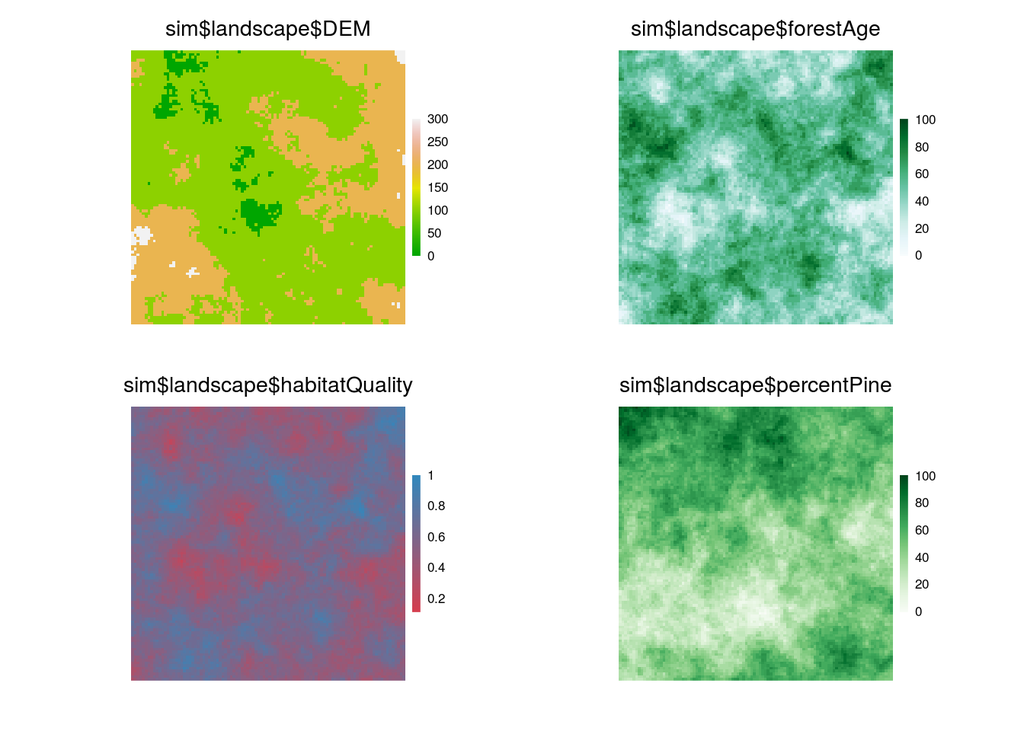

```
## class       : RasterLayer
## dimensions  : 100, 100, 10000  (nrow, ncol, ncell)
## resolution  : 1, 1  (x, y)
## extent      : -50, 50, -50, 50  (xmin, xmax, ymin, ymax)
## coord. ref. : NA
## data source : in memory
## names       : climate
## values      : 3.57101, 13.57101  (min, max)
```

```
## legendRange is not wide enough, scaling to min and max raster values
```

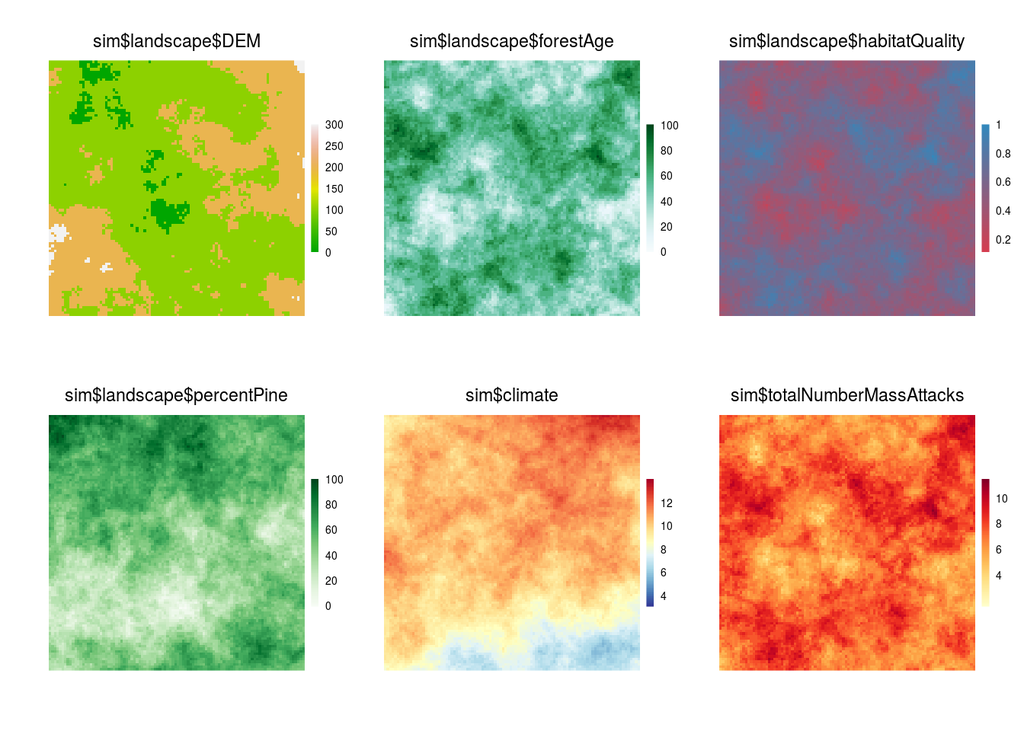

```
## legendRange is not wide enough, scaling to min and max raster values
```

[figure not shown]

[output not shown]

[output cut: 25 more lines]

```
## resolution  : 1, 1  (x, y)
## extent      : -50, 50, -50, 50  (xmin, xmax, ymin, ymax)
## coord. ref. : NA
## data source : in memory
## names       : climate
## values      : 40.41254, 50.41254  (min, max)
##
## class       : RasterLayer
## dimensions  : 100, 100, 10000  (nrow, ncol, ncell)
## resolution  : 1, 1  (x, y)
## extent      : -50, 50, -50, 50  (xmin, xmax, ymin, ymax)
## coord. ref. : NA
## data source : in memory
## names       : climate
## values      : 44.64684, 54.64684  (min, max)
```

```r
clearPlot()

simB79forced <- simInit(
  times=list(start=0.0, end=10.0, timeunit="year"),
  params=list(
    .globals=list(stackName="landscape", climateMap="climate"),
    MPBRedTopGrowth_B79forced=list(.plotInitialTime=1, .plotInterval=1),
    MPBRedTopLandscape=list(.plotInitialTime=1, .plotInterval=1, nx=100, ny=100),
    MPBRedTopClimate=list(.plotInitialTime=1, .plotInterval=1, nx=100, ny=100, updateInterval=1),
    MPBRedTopMassAttacks=list(.plotInitialTime=1, .plotInterval=NA),
    MPBRedTopImpacts=list(.plotInitialTime=1, .plotInterval=1)
  ),
  modules=list("MPBRedTopLandscape",
               "MPBRedTopMassAttacks",
               "MPBRedTopClimate",
               "MPBRedTopDispersal_Null",
               "MPBRedTopGrowth_B79forced", ## specify which growth module is used
               "MPBRedTopImpacts"),
  paths=list(modulePath="./modules")
) %>% spades(., debug=FALSE)
```

Simulation diagrams:

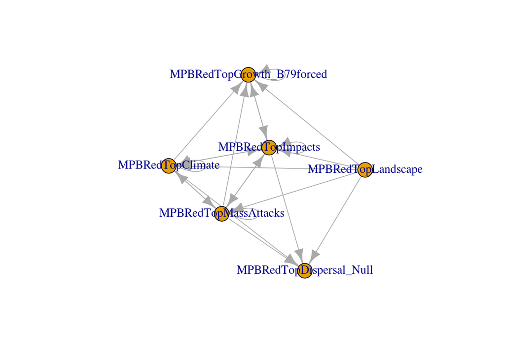

```r
moduleDiagram(simB79forced)
```

```r
objectDiagram(simB79forced)
```

[interactive chart not shown]

```r
eventDiagram(simB79forced, startDate="0000-06-01") # startDate required
```

[interactive chart not shown]

# Literature Cited

[output not shown]

“Berryman 1979”,“Berryman 1999”,“Powell & Bentz 2009”,“Trczinski & Reid 2009”,“MacQuarrie & Cooke 2011”,“Cooke et al. 2016”,“Cooke et al. 2016”